# **Impact of Severe Weather Events on Public Health and Economy in the United States**

Xiang Wang in Summer 2015

### Abstract

Storms and other severe weather events can cause both public health and economic problems for communities and municipalities. Many severe events can result in fatalities, injuries, and property damage, and preventing such outcomes to the extent possible is a key concern. In this report, the impact of different weather events on public health and economy was analyzed from the storm database collected from the U.S. National Oceanic and Atmospheric Administration’s (NOAA) from 1950 - 2011. The statistics of fatalities, injuries, property and crop damage were used to analyze which types of event were most harmful to the population health and economy. It was found that excessive heat and tornado were most harmful to population health while flood, drought, and hurricane/typhoon had the greatest economic consequences.

- The basic `goal` of this project is to explore the `NOAA Storm Database` and answer some basic questions about severe weather events.

### Questions

Your data analysis must address the following questions: 1. Across the United States, which types of events (as indicated in the `EVTYPE` variable) are most harmful with respect to population health? 2. Across the United States, which types of events have the greatest economic consequences?

### Data Processing

```r
library(R.utils)
```

```r
library(ggplot2)
library(plyr)
require(gridExtra)
# read a zip data file without unzipping it
storm <- read.csv("StormData.csv.bz2", header=T, sep=',')
str(storm)
```

```
## 'data.frame':    902297 obs. of  37 variables:
##  $ STATE__   : num  1 1 1 1 1 1 1 1 1 1 ...
##  $ BGN_DATE  : Factor w/ 16335 levels "1/1/1966 0:00:00",..: 6523 6523 4242 11116 2224 2224 2260 383 3980 3980 ...
##  $ BGN_TIME  : Factor w/ 3608 levels "00:00:00 AM",..: 272 287 2705 1683 2584 3186 242 1683 3186 3186 ...
##  $ TIME_ZONE : Factor w/ 22 levels "ADT","AKS","AST",..: 7 7 7 7 7 7 7 7 7 7 ...
##  $ COUNTY    : num  97 3 57 89 43 77 9 123 125 57 ...
##  $ COUNTYNAME: Factor w/ 29601 levels "","5NM E OF MACKINAC BRIDGE TO PRESQUE ISLE LT MI",..: 13513 1873 4598 10592 4372 10094 1973 23873 24418 4598 ...
##  $ STATE     : Factor w/ 72 levels "AK","AL","AM",..: 2 2 2 2 2 2 2 2 2 2 ...
##  $ EVTYPE    : Factor w/ 985 levels "   HIGH SURF ADVISORY",..: 834 834 834 834 834 834 834 834 834 834 ...
##  $ BGN_RANGE : num  0 0 0 0 0 0 0 0 0 0 ...
##  $ BGN_AZI   : Factor w/ 35 levels "","  N"," NW",..: 1 1 1 1 1 1 1 1 1 1 ...
##  $ BGN_LOCATI: Factor w/ 54429 levels ""," Christiansburg",..: 1 1 1 1 1 1 1 1 1 1 ...
##  $ END_DATE  : Factor w/ 6663 levels "","1/1/1993 0:00:00",..: 1 1 1 1 1 1 1 1 1 1 ...
##  $ END_TIME  : Factor w/ 3647 levels ""," 0900CST",..: 1 1 1 1 1 1 1 1 1 1 ...
##  $ COUNTY_END: num  0 0 0 0 0 0 0 0 0 0 ...
```

[output cut: 23 more lines]

The events in the database start in 1950 and end in 2011. There are generally fewer events recorded in the early years of the database. So here data from recent years should be more complete.

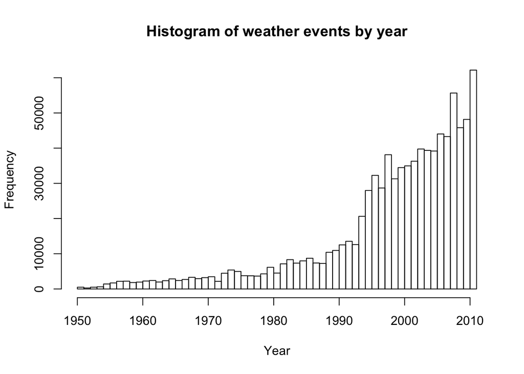

```r
storm$year <- as.numeric(format(as.Date(storm$BGN_DATE, format = "%m/%d/%Y %H:%M:%S"), "%Y"))
hist(storm$year, breaks = 50, main = "Histogram of weather events by year", xlab = "Year")
```

Based on the histogram above, the number of events starts to significantly increase since 1980. Thus, the subset of the data from 1980 to 2011 to get most out of good records.

```r
storm <- storm[storm$year >= 1980, ]
# dim(storm) # 826931, 38
```

### Impact on Public Health

The numbers of fatalities and injuries caused by severe weather events were checked to get the ten most frequent types of events.

```r
rank <- function(variable, top = 10, dataset = storm) {
    index <- which(colnames(dataset) == variable)
    a <- aggregate(dataset[, index], by = list(dataset$EVTYPE), FUN = "sum")
    names(a) <- c("EVTYPE", variable)
    a <- arrange(a, a[, 2], decreasing = T)
    a <- head(a, n = top)
    a <- within(a, EVTYPE <- factor(x = EVTYPE, levels = a$EVTYPE))
    return(a)
}

fatalities <- rank("FATALITIES", dataset = storm)
injuries <- rank("INJURIES", dataset = storm)
```

### Impact on Economy

We will convert the damage data from property and crop into comparable numerical forms according to the meaning of units described in the code book ([Storm Events](http://ire.org/nicar/database-library/databases/storm-events/)). Both `PROPDMGEXP` and `CROPDMGEXP` columns record a multiplier for each observation where we have Hundred (H), Thousand (K), Million (M) and Billion (B).

```r
economy <- function(dataset = storm, b, c) {
  total <- dim(dataset)[2]
  index <- which(colnames(dataset) == b)
  dataset[, index] <- as.character(dataset[, index])
  logic <- !is.na(toupper(dataset[, index]))
  dataset[logic & toupper(dataset[, index]) == "B", index] <- "9"
  dataset[logic & toupper(dataset[, index]) == "M", index] <- "6"
  dataset[logic & toupper(dataset[, index]) == "K", index] <- "3"
  dataset[logic & toupper(dataset[, index]) == "H", index] <- "2"
  dataset[logic & toupper(dataset[, index]) == "", index] <- "0"
  dataset[, index] <- as.numeric(dataset[, index])
  dataset[is.na(dataset[, index]), index] <- 0
  dataset <- cbind(dataset, dataset[, index - 1] * 10^dataset[, index])
  names(dataset)[total + 1] <- c
  return(dataset)
}

storm <- economy(storm, "PROPDMGEXP", "propertyDamage")
storm <- economy(storm, "CROPDMGEXP", "cropDamage")
names(storm)
```

```
##  [1] "STATE__"        "BGN_DATE"       "BGN_TIME"       "TIME_ZONE"
##  [5] "COUNTY"         "COUNTYNAME"     "STATE"          "EVTYPE"
##  [9] "BGN_RANGE"      "BGN_AZI"        "BGN_LOCATI"     "END_DATE"
## [13] "END_TIME"       "COUNTY_END"     "COUNTYENDN"     "END_RANGE"
## [17] "END_AZI"        "END_LOCATI"     "LENGTH"         "WIDTH"
## [21] "F"              "MAG"            "FATALITIES"     "INJURIES"
## [25] "PROPDMG"        "PROPDMGEXP"     "CROPDMG"        "CROPDMGEXP"
## [29] "WFO"            "STATEOFFIC"     "ZONENAMES"      "LATITUDE"
## [33] "LONGITUDE"      "LATITUDE_E"     "LONGITUDE_"     "REMARKS"
## [37] "REFNUM"         "year"           "propertyDamage" "cropDamage"
```

```r
property <- rank("propertyDamage", dataset = storm)
crop <- rank("cropDamage", dataset = storm)
```

### Results

In terms of the impact on public health, two sorted lists of severe weather events were shown below by the number of people badly affected.

```r
fatalities
```

```
##            EVTYPE FATALITIES
## 1         TORNADO       2274
## 2  EXCESSIVE HEAT       1903
## 3     FLASH FLOOD        978
## 4            HEAT        937
## 5       LIGHTNING        816
## 6       TSTM WIND        504
## 7           FLOOD        470
## 8     RIP CURRENT        368
## 9       HIGH WIND        248
## 10      AVALANCHE        224
```

```r
injuries
```

```
##               EVTYPE INJURIES
## 1            TORNADO    37971
## 2          TSTM WIND     6957
## 3              FLOOD     6789
## 4     EXCESSIVE HEAT     6525
## 5          LIGHTNING     5230
## 6               HEAT     2100
## 7          ICE STORM     1975
## 8        FLASH FLOOD     1777
## 9  THUNDERSTORM WIND     1488
## 10              HAIL     1361
```

Based on the data from above list, a pair of graphs of total fatalities and total injuries affected by these severe weather events were created below.

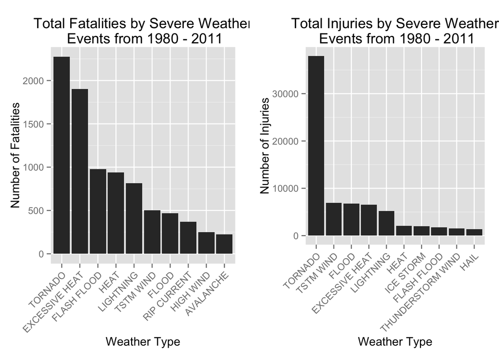

```r
plot_fatalities <- qplot(EVTYPE, data = fatalities, weight = FATALITIES, geom = "bar", binwidth = 1) +
    scale_y_continuous("Number of Fatalities") +
    theme(axis.text.x = element_text(angle = 45, hjust = 1)) +
    xlab("Weather Type") +
    ggtitle("Total Fatalities by Severe Weather\n Events from 1980 - 2011")
plot_injuries <- qplot(EVTYPE, data = injuries, weight = INJURIES, geom = "bar", binwidth = 1) +
    scale_y_continuous("Number of Injuries") +
    theme(axis.text.x = element_text(angle = 45, hjust = 1)) +
    xlab("Weather Type") +
    ggtitle("Total Injuries by Severe Weather\n Events from 1980 - 2011")
    grid.arrange(plot_fatalities, plot_injuries, ncol = 2)
```

In terms of the impact on economy, two sorted lists were made below by the amount of money cost by damages.

```r
property
```

```
##               EVTYPE propertyDamage
## 1              FLOOD   144657709807
## 2  HURRICANE/TYPHOON    69305840000
## 3            TORNADO    43648796346
## 4        STORM SURGE    43323536000
## 5        FLASH FLOOD    16822673978
## 6               HAIL    15735267513
## 7          HURRICANE    11868319010
## 8     TROPICAL STORM     7703890550
## 9       WINTER STORM     6688497251
## 10         HIGH WIND     5270046295
```

```r
crop
```

```
##               EVTYPE  cropDamage
## 1            DROUGHT 13972566000
## 2              FLOOD  5661968450
## 3        RIVER FLOOD  5029459000
## 4          ICE STORM  5022113500
## 5               HAIL  3025954473
## 6          HURRICANE  2741910000
## 7  HURRICANE/TYPHOON  2607872800
## 8        FLASH FLOOD  1421317100
## 9       EXTREME COLD  1292973000
## 10      FROST/FREEZE  1094086000
```

Based on the data from above list, a pair of graphs of total property damage and total crop damage affected by these severe weather events were created.

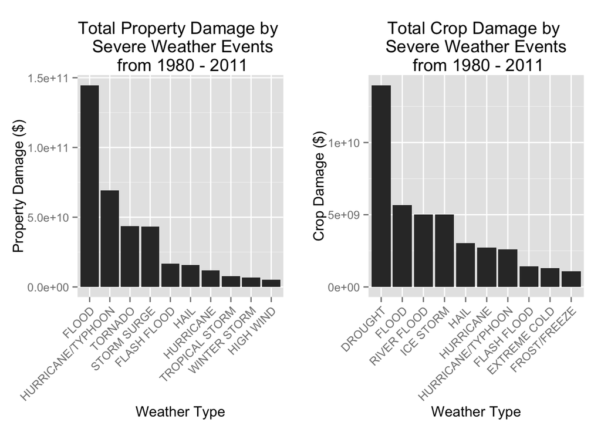

```r
plot_property <- qplot(EVTYPE, data = property, weight = propertyDamage, geom = "bar", binwidth = 1) +
    theme(axis.text.x = element_text(angle = 45, hjust = 1)) +
    scale_y_continuous("Property Damage ($)") +
    xlab("Weather Type") +
    ggtitle("Total Property Damage by \n Severe Weather Events\n from 1980 - 2011")
plot_crop <- qplot(EVTYPE, data = crop, weight = cropDamage, geom = "bar", binwidth = 1) +
    theme(axis.text.x = element_text(angle = 45, hjust = 1)) +
    scale_y_continuous("Crop Damage ($)") +
    xlab("Weather Type") +
    ggtitle("Total Crop Damage by \nSevere Weather Events\n from 1980 - 2011")
    grid.arrange(plot_property, plot_crop, ncol = 2)
```

Based on the histograms above, we found that **flood** and **hurricane/typhoon** caused most property damage; **drought** and **flood** caused most crop damage in the United States from 1980 to 2011.

### Conclusion

**excessive heat** and **tornado** were most harmful to population health while **flood**, **drought**, and **hurricane/typhoon** had the greatest economic consequences.